# Task 1 – Curse of dimensionality and effect of sample size

## Import libraries

```python
import numpy as np
import matplotlib.pyplot as plt
```

## For D from 1 to 15 dimensions, simulate 1000 random D-dimensional points, where the value in each dimension is uniformly randomly distributed between -1 and +1.

```python
points = {}
for dimension in range(1,16):
   points[dimension] = np.random.rand(1000, dimension)*2 - 1
```

## Part a : Calculate the fraction of these points that are within distance 1 of the origin, giving an approximation of the volume of the unit hypersphere to the hypercube inscribing it.

```python
def distance_to_origin(point):
    return np.sqrt(np.sum(point**2))
```

```python
fractions = {}
for key,value in points.items():
    distances = np.apply_along_axis(distance_to_origin,1,value)
    fraction = np.sum(distances<=1)/len(distances)
    fractions[key] = fraction
```

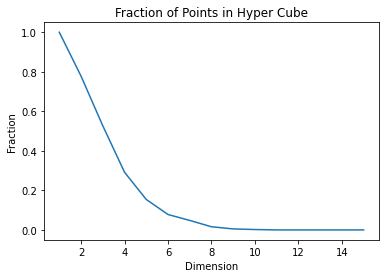

```python
dimensions = list(fractions.keys())
fractions_ = list(fractions.values())
plt.plot(dimensions,fractions_)
plt.xlabel("Dimension")
plt.ylabel("Fraction")
plt.title("Fraction of Points in Hyper Cube")
plt.show()
```

## Part b: Use the value of this fraction at D = 2 and D = 3 to get estimates for the value of pi (Π) as you know the area (for D = 2) and volume (for D = 3) formulae for these cases.

```python
#fractions_[1] -> D=2 ,  fractions_[2] -> D=3  and pi calculated from area and volume formulas for circle 2d pi*r*r square 4*r*r we can find fraction*4=pi in 2-D  .
#For 3d v= (4/3)* π *r^3 for sphere v= 8 *π * r^3 for cube then pi = 6*fraction
pi_value_2d = 4*fractions_[1]
pi_value_3d = 6*fractions_[2]
print("π is estimated from dimension 2 fraction as: "+ str(pi_value_2d))
print("π is estimated from dimension 3 fraction as: "+ str(pi_value_3d))
```

```
π is estimated from dimension 2 fraction as: 3.112
π is estimated from dimension 3 fraction as: 3.162
```

## Part c: Perform the calculations in part (b) with larger sample sizes. You can use the following set: {5000,10000, 25000, 50000, 100000}. Visualize the estimated Π for D = 2 and D = 3 cases. Comment on your results

```python
sizes = [500, 1000, 5000, 8000, 10000,25000, 35000, 40000,50000, 70000, 80000, 100000]
pi_values_size_3d = {}
pi_values_size_2d = {}
points_size = {}
for size in sizes:
  for dimension in range(2,4):
    points[dimension] = np.random.rand(size, dimension)*2 - 1
  distances_2d = np.apply_along_axis(distance_to_origin,1,points[2])
  fraction_2d = np.sum(distances_2d<=1)/len(distances_2d)
  distances_3d = np.apply_along_axis(distance_to_origin,1,points[3])
  fraction_3d = np.sum(distances_3d<=1)/len(distances_3d)
  pi_value_2d = 4*fraction_2d
  pi_value_3d = 6*fraction_3d
  pi_values_size_2d[size] = pi_value_2d
  pi_values_size_3d[size] = pi_value_3d
```

```python
print(pi_values_size_3d)
print(pi_values_size_2d)
```

```
{500: 3.2880000000000003, 1000: 3.018, 5000: 3.1548000000000003, 8000: 3.1769999999999996, 10000: 3.1566, 25000: 3.1708799999999995, 35000: 3.1572, 40000: 3.1648500000000004, 50000: 3.14628, 70000: 3.1595142857142857, 80000: 3.17325, 100000: 3.12798}
{500: 3.12, 1000: 3.072, 5000: 3.168, 8000: 3.166, 10000: 3.1532, 25000: 3.14576, 35000: 3.1562285714285716, 40000: 3.1252, 50000: 3.13928, 70000: 3.135542857142857, 80000: 3.1401, 100000: 3.13744}
```

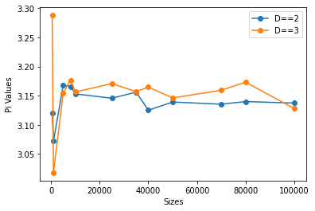

```python
pi_values_2d = list(pi_values_size_2d.values())
pi_values_3d = list(pi_values_size_3d.values())
plt.plot(sizes,pi_values_2d, label="D==2",marker = "o")
plt.plot(sizes,pi_values_3d, label="D==3",marker = "o")
plt.xlabel("Sizes")
plt.ylabel("Pi Values")
plt.legend()
plt.show()
```

## Part d: Repeat this simulation, sampling 1000 D-dimensional points from 1 to 15 dimensions, where the value in each dimension is uniformly randomly distributed between -1 and +1. For each value of D, generate an additional 100 test instances and calculate the distance to each test instance’s nearest neighbor. Plot the average distance from the test instances to their nearest neighbors as a function of D.

```python
# Create D-dimensional samples

points = {}
test_data = {}

for dimension in range(1,16):
    points[dimension] = np.random.rand(1000,dimension)*2 - 1

for dimension in range(1,16):
    test_data[dimension] = np.random.rand(100,dimension)*2 - 1
```

```python
# This function calculate the distance between two points of the same dimension
def dist_between(point1,point2):

    distance = 0
    for i in range(0,len(point1)):
        distance += (point1[i]-point2[i])**2
    return distance**0.5
```

```python
# Calculate the mean distances to the nearest neighbors
mean_distances = {}
for dimension in range(1,16):
  min_distances = []
  for point1 in test_data[dimension]:
      distance = []
      for point2 in points[dimension]:
          distance.append(dist_between(point1, point2))
      min_distances.append(min(distance))
  mean_distances[dimension] = np.mean(min_distances)
```

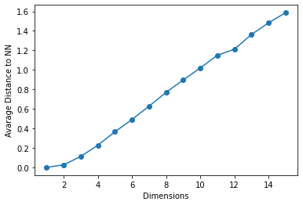

```python
dimensions = list(mean_distances.keys())
distances = list(mean_distances.values())
plt.plot(dimensions, distances, marker="o")
plt.xlabel("Dimensions")
plt.ylabel("Avarage Distance to NN")
plt.show()
```

# Task 2

## Part a: Read image as a variable in R/Python. You need to install “jpeg” package to read image into a variable if you use R. For Python, an alternative is to use matplotlib package. What is the structure of the variable that stores the image? What is the dimension? a. Display the image.

```python
image = plt.imread("photo.jpg")
print(image)
print(image.shape)
print(type(image))
```

```
[[[250 236 233]
  [250 236 233]
  [250 236 233]
  ...
  [242 227 220]
  [242 227 220]
  [242 227 220]]

 [[250 236 233]
  [250 236 233]
  [250 236 233]
  ...
  [242 227 220]
  [242 227 220]
  [242 227 220]]

 [[250 236 233]
  [250 236 233]
  [250 236 233]
  ...
  [242 227 220]
  [242 227 220]
  [242 227 220]]

 ...

 [[231 222 213]
  [231 222 213]
  [231 222 213]
  ...
  [239 236 219]
  [238 237 219]
  [236 237 219]]

 [[231 222 213]
  [231 222 213]
  [231 222 213]
  ...
  [239 236 219]
  [238 237 219]
  [236 237 219]]

 [[231 222 213]
  [231 222 213]
  [231 222 213]
  ...
  [239 236 219]
  [238 237 219]
  [236 237 219]]]
(512, 512, 3)
<class 'numpy.ndarray'>
```

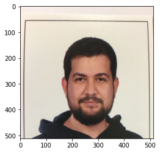

```python
plt.imshow(image);
```

## Part b: Display each channel as separate image

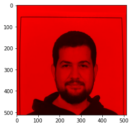

```python
image_r = np.zeros((512,512,3), dtype="uint8")
image_r[:,:,0] = image[:,:,0]
plt.imshow(image_r);
```

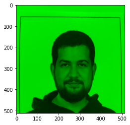

```python
image_g = np.zeros((512,512,3), dtype="uint8")
image_g[:,:,1] = image[:,:,1]
plt.imshow(image_g);
```

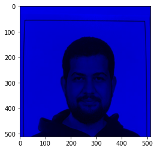

```python
image_b = np.zeros((512,512,3), dtype="uint8")
image_b[:,:,2] = image[:,:,2]
plt.imshow(image_b);
```

## Task c: For each channel, take the average of the columns and plot the average as a line plot for each channel on a single plot.

```python
red_channel = image_r[:,:,0]
green_channel = image_g[:,:,1]
blue_channel = image_b[:,:,2]
```

```python
r_colmeans = red_channel.mean(axis=0)


g_colmeans = green_channel.mean(axis=0)

b_colmeans = blue_channel.mean(axis=0)
```

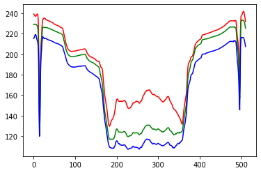

```python
# Plot the means for each channel
plt.plot(r_colmeans, color="r")
plt.plot(g_colmeans,color="g")
plt.plot(b_colmeans, color="b")
plt.show()
```

## Task d: For each channel, subtract one half of the image from the other half

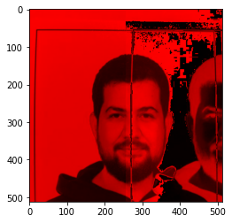

```python
# For the red part
red_first_half = image_r[:,:256,:]
red_second_half = image_r[:,256:,:]
red_new_second_half = red_second_half-red_first_half
red_new_second_half = red_new_second_half.clip(0)
new_red_image = np.concatenate((red_first_half,red_new_second_half),axis=1)
plt.imshow(new_red_image);
```

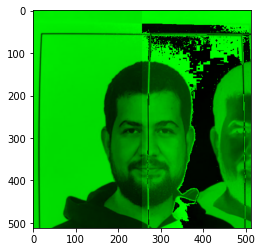

```python
# For the green part
green_first_half = image_g[:,:256,:]
green_second_half = image_g[:,256:,:]
green_new_second_half = green_second_half-green_first_half
green_new_second_half = green_new_second_half.clip(0)
new_green_image = np.concatenate((green_first_half,green_new_second_half),axis=1)
plt.imshow(new_green_image);
```

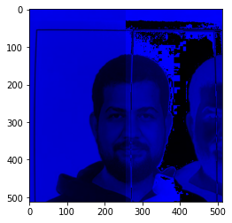

```python
# For the blue part
blue_first_half = image_b[:,:256,:]
blue_second_half = image_b[:,256:,:]
blue_new_second_half = blue_second_half-blue_first_half
blue_new_second_half = blue_new_second_half.clip(0)
new_blue_image = np.concatenate((blue_first_half,blue_new_second_half),axis=1)
plt.imshow(new_blue_image);
```

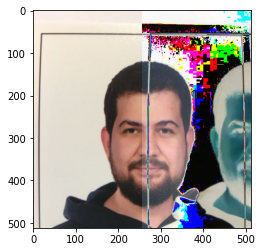

```python
# Display the new image
new_image = np.zeros(image.shape, dtype="uint8")

new_image[:,:,0] = new_red_image[:,:,0]
new_image[:,:,1] = new_green_image[:,:,1]
new_image[:,:,2] = new_blue_image[:,:,2]

plt.imshow(new_image);
```

## Task e: In order to create a noisy image, add a random noise from uniform distribution with minimum value of 0 and a maximum value of “0.1 * maximum pixel value observed” to each pixel value for each channel of original image.

```python
#maximum pixel value observed
print(np.max(red_channel))
print(np.max(green_channel))
print(np.max(blue_channel))
```

```
255
255
243
```

```python
noisy_image=image.copy()

noise =  np.random.rand(512,512,3)*255*0.1
print(noise)
```

```
[[[ 9.06591937 10.71434821 12.43183643]
  [22.59177668 10.63336707  1.35539499]
  [ 6.15299524  6.09919882  9.41595513]
  ...
  [12.32568086 15.34244633 23.23430611]
  [11.27096499  7.04826506 11.36998231]
  [19.44795212 18.33701862  6.32993368]]

 [[14.72579306 15.34310611 19.83683122]
  [ 0.11549376 10.46950131  2.12092592]
  [20.37138218  2.6677413  25.22042241]
  ...
  [21.26470054 19.03697646 15.79466391]
  [12.83197419 13.94313698  8.15851898]
  [ 4.40701798 12.22733694 11.96402153]]

 [[22.28528263 15.27229498 22.56488747]
  [ 2.8762064   7.35008122 24.62028371]
  [21.27717023  1.82628438 24.46664927]
  ...
  [19.86176321 17.58457418  2.7311729 ]
  [23.26310707 20.50601612  0.07880039]
  [15.19484271 12.48313329 21.47531295]]

 ...

 [[ 9.70858642 11.35900932  1.97516005]
  [18.05025753 23.92701805 16.88317993]
  [ 2.64098219 15.21623669 14.55991241]
  ...
  [13.49603701  2.49648286 22.03297438]
  [14.40286246 19.36465956 16.04919553]
  [11.16921613 15.33807705 22.53674455]]

 [[ 9.07523631 18.56535059  5.07896951]
  [19.56464977 17.50738935  1.81113686]
  [ 1.67521653 15.12577281 19.25008723]
  ...
  [ 1.53552074  9.12183331 15.86361846]
  [ 2.57670381  6.14542918 19.77179933]
  [15.79032694 10.03994339  6.29939039]]

 [[ 8.69583648 12.06431081 22.08573148]
  [16.48024371 16.83236767 23.33184542]
  [19.41652274 10.22228377  3.67153869]
  ...
  [18.25640873 14.74034526 24.25434984]
  [11.63860483 14.56987371 14.59843092]
  [10.65572444 13.75576565  0.46498437]]]
```

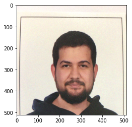

```python
noisy_image = noisy_image + noise
noisy_image = noisy_image.clip(0,255)
noisy_image = noisy_image.astype(int)
plt.imshow(noisy_image)
```

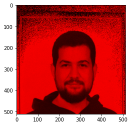

```python
noisy_red = np.zeros(noisy_image.shape, dtype="uint8")
#Maximum value pixel in red channel was 255 so noise created according to this value.
noise =  np.random.rand(512,512)*255*0.1
noisy_red[:,:,0] = image[:,:,0]+noise
noisy_image = noisy_image.clip(0,255)
noisy_image = noisy_image.astype(int)
plt.imshow(noisy_red)
```

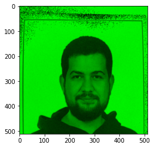

```python
noisy_green = np.zeros(noisy_image.shape, dtype="uint8")
#Maximum value pixel in green channel was 255 so noise created according to this value.
noise =  np.random.rand(512,512)*255*0.1
noisy_green[:,:,1] = image[:,:,1]+noise
noisy_image = noisy_image.clip(0,255)
noisy_image = noisy_image.astype(int)
plt.imshow(noisy_green)
```

[figure not shown]

```python
noisy_blue = np.zeros(noisy_image.shape, dtype="uint8")
#Maximum value pixel in blue channel was 243 so noise created according to this value.
noise =  np.random.rand(512,512)*243*0.1
noisy_blue[:,:,1] = image[:,:,1]+noise
noisy_image = noisy_image.clip(0,255)
noisy_image = noisy_image.astype(int)
plt.imshow(noisy_blue)
```

```python
%%shell
jupyter nbconvert --to html /content/IE582_HW1_Cumhur_Kılıç.ipynb
```

```
[NbConvertApp] Converting notebook /content/IE582_HW1_Cumhur_Kılıç.ipynb to html
[NbConvertApp] Writing 1148008 bytes to /content/IE582_HW1_Cumhur_Kılıç.html
```